# Data analysis using statistical software: Basic Operation of R

Sho Kuroda / 黒田翔

2024-03-23 (Last update: 2024-03-23)

「統計ソフトによるデータ解析」（早稲田大学商学研究科・会計研究科）

# 1 Basic operating instructions / 基本的な操作

詳細は [An Introduction to R](https://intro2r.com/) を参照．

## 1.1 Basic arithmetic operations / 四則演算

```r
1 + 1  # addition
```

```
## [1] 2
```

```r
2 - 3  # subtraction
```

```
## [1] -1
```

```r
2 * 3  # multiplication
```

```
## [1] 6
```

```r
2 / 3  # division
```

```
## [1] 0.6666667
```

## 1.2 Comment out / コメントアウト

`#` 記号から後ろはコメントアウトされる（＝実行されない）． 自分用のメモを書いておくのに便利．

```r
1 + 2 + 10
```

```
## [1] 13
```

```r
1 + 2 # + 10
```

```
## [1] 3
```

## 1.3 Power, square root, log, exponent / べき乗，平方根，対数，指数

```r
2 ^ 3  # 2 to the power of 3
```

```
## [1] 8
```

```r
2 ** 3  # same as above
```

```
## [1] 8
```

```r
sqrt(16)  # square root
```

```
## [1] 4
```

```r
log(10)  # natural logarithm
```

```
## [1] 2.302585
```

```r
exp(1)  # exponential
```

```
## [1] 2.718282
```

`sqrt`, `log` などは関数． 「`関数名(引数)`」の形で使う． 「`引数`」が関数の入力．

以下の例では関数 $f$ (`sqrt`) に対して $x = 16$ が引数（関数の入力）で，$4$ が結果（関数の出力）．

$$f(x) = \sqrt{x}, \quad f(16) =
\sqrt{16} = 4.$$

## 1.4 Help / ヘルプ

関数の機能や使い方を調べる．

```r
?exp
help(exp)  # same as above
```

## 1.5 Objects / オブジェクト

円周率 $\pi$ などの定数は既に割り当てられている．

```r
pi  # pi (circle ratio)
```

```
## [1] 3.141593
```

この `pi` は「オブジェクト」と呼ばれ，数値が割り当てられている．

実は，ユーザーは任意の数字を適当な「オブジェクト」として定義することができる． 数値を「オブジェクト」に割り当てることで，数値を複数の箇所で繰り返し使うことができる．

「`オブジェクト名 <- 数値`」の形式で割り当てる． 「`<-`」は割り当て（または代入）を行う演算子で，「`<`」（小なり）と「`-`」（ハイフン）を組み合わせて使用．

```r
x <- 1  # "x" is the object name
x + 1
```

```
## [1] 2
```

```r
x + 2
```

```
## [1] 3
```

```r
x <- 10  # override
x + 5
```

```
## [1] 15
```

オブジェクト名はアルファベットではじめる． 2文字目以降は数字やアンダーバーを使ってよい． 演算記号など（`+ - * / ( ) [ ] ! ? < > = | ^ # $ % &` etc.）は使用不可．

```r
x_3digit <- 500
```

オブジェクトには数字だけではなく文字列を代入することもできる． ただし，文字列をダブルクオーテーション `""` で囲まなければならない．

```r
univ_name <- "Waseda"
paste(univ_name, "University")  # "paste" function concatenate strings
```

```
## [1] "Waseda University"
```

## 1.6 Vectors / ベクトル

上ではスカラーの数字を考えていたが，数ベクトル（すうベクトル）を扱うこともできる． ベクトルを作成するには `c` 関数を使い，ベクトルの要素を引数として指定する．

```r
c(1, 2, 6)  # combine values into vector
```

```
## [1] 1 2 6
```

欠損値 (missing value) は `NA` で表す．

```r
c(1, NA, 6)
```

```
## [1]  1 NA  6
```

連続する整数のベクトルを生成するにはコロン `:` を使うのが便利．

```r
1:5
```

```
## [1] 1 2 3 4 5
```

```r
100:105
```

```
## [1] 100 101 102 103 104 105
```

### 1.6.1 Assignment to objects / オブジェクトへの代入

ベクトルもスカラーと同様にオブジェクトに代入することができる．

```r
x <- c(1, 2, 6)  # assign vector to object "x"
x
```

```
## [1] 1 2 6
```

```r
x + 10
```

```
## [1] 11 12 16
```

### 1.6.2 Extract a portion of the vector / ベクトルの一部を取り出す

ベクトルの特定の要素を抽出するには，`min` （ベクトルの要素のうち最小の値を返す関数）のような関数を使ったり，あるいは `[ ]` を使って何番目の要素かを直接指定する方法がある．

```r
min(x)  # minimum value
```

```
## [1] 1
```

```r
max(x)  # maximum value
```

```
## [1] 6
```

```r
x[2]  # extract 2nd value
```

```
## [1] 2
```

```r
x[c(2, 3)]  # extract 2nd and 3rd values
```

```
## [1] 2 6
```

```r
x[2:3]  # same as above
```

```
## [1] 2 6
```

特定の条件を満たす要素のみを抽出することもできる． 「等しい」は `==` （等号が2つ），「等しくない」は `!=` （エクスクラメーションマークと等号）を使う．

注：等号1つ `=` は（`<-` と同様に）代入を表す演算記号なので要注意．

```r
x[x > 1]
```

```
## [1] 2 6
```

```r
x > 1  # logical index
```

```
## [1] FALSE  TRUE  TRUE
```

```r
x[x == 2]  # "==" means `equal to`
```

```
## [1] 2
```

```r
x[x != 2]  # "!=" means `not equal to`
```

```
## [1] 1 6
```

特定の要素に別の値を代入して上書きすることもできる．

```r
x
```

```
## [1] 1 2 6
```

```r
x[2] <- 100
x
```

```
## [1]   1 100   6
```

### 1.6.3 Multiple vectors / 複数のベクトル

複数のベクトルに対して演算することもできる．

```r
x2 <- c(1, 3, 4)  # another vector
x + x2
```

```
## [1]   2 103  10
```

ベクトルの内積（スカラー積）は `%*%` で計算される．

```r
x %*% x2
```

```
##      [,1]
## [1,]  325
```

要素ごとの積は `*` で計算される．

```r
x * x2
```

```
## [1]   1 300  24
```

ベクトルとスカラーの積はベクトルの各要素とスカラーの積のベクトルとして計算される．

```r
x * 10
```

```
## [1]   10 1000   60
```

### 1.6.4 String vector / 文字列のベクトル

文字列のベクトルを作成することもできる．

```r
beatles_name <- c("John", "Paul", "George", "Ringo")
```

## 1.7 Other tips: semicolon

To write multiple commands on a single line, join them with semicolon “;”.

1行に複数のコマンドを書く場合は「;」で繋ぐ．

```r
x; x + x2 + 1
```

```
## [1]   1 100   6
```

```
## [1]   3 104  11
```

# 2 Dataframe / データフレーム

ベクトルを束ねて行と列からなるデータフレームを作成できる． ただし，ベクトルの各要素は互いに対応していなければならない（例：1つ目のベクトルのn番目の要素と，2つ目のベクトルのn番目の要素は，同じ人や同じ企業のデータが割り当てられている）．

## 2.1 Create data frames / データフレームを作成する

データフレームを作成するには `data.frame` 関数を使い，引数として「`列名（変数名） = ベクトルのオブジェクト`」を指定する．

```r
beatles_name <- c("John", "Paul", "George", "Ringo")
beatles_born <- c(1940, 1942, 1943, 1940)  # year of birth
beatles_decease <- c(1980, NA, NA, NA)  # year of death
beatles_height <- c(179, 180, 178, 170)  # in cm
beatles <- data.frame(name = beatles_name, born = beatles_born, decease = beatles_decease,
                      height = beatles_height)
beatles
```

```
##     name born decease height
## 1   John 1940    1980    179
## 2   Paul 1942      NA    180
## 3 George 1943      NA    178
## 4  Ringo 1940      NA    170
```

以下のように作成することもできる．

```r
beatles2 <- data.frame(name = c("John", "Paul", "George", "Ringo") , born = c(1940, 1942, 1943, 1940),
                       decease = c(1980, NA, NA, NA), height = c(179, 180, 178, 170))
beatles2
```

```
##     name born decease height
## 1   John 1940    1980    179
## 2   Paul 1942      NA    180
## 3 George 1943      NA    178
## 4  Ringo 1940      NA    170
```

## 2.2 Extract a portion of the data frame / データフレームの一部を取り出す

データフレームの特定の要素を抽出するには， `[ ]` を使って何行目・何列目かを指定したり，あるいは「`データフレーム名$列名`」のように `$` （ドル）記号を使って列名（変数名）を指定する．

```r
beatles[1, ]  # 1st row (John)
```

```
##   name born decease height
## 1 John 1940    1980    179
```

```r
beatles[, 2]  # 2nd column (born)
```

```
## [1] 1940 1942 1943 1940
```

```r
beatles[, "born"]  # same as above
```

```
## [1] 1940 1942 1943 1940
```

```r
beatles$born  # column named "born" (year of birth)
```

```
## [1] 1940 1942 1943 1940
```

```r
beatles[1, 2]  # 1st row (John) and 2nd column (born)
```

```
## [1] 1940
```

```r
beatles[1:2, 2:3]
```

```
##   born decease
## 1 1940    1980
## 2 1942      NA
```

```r
beatles[1:2, c("born", "decease")]  # same as above
```

```
##   born decease
## 1 1940    1980
## 2 1942      NA
```

## 2.3 Display the structure of an object / オブジェクトの構造

`str` 関数で行数（サンプルサイズ），列数（変数の数），各列のデータの型（文字列，数字，etc.）を簡単に確認できる．

```r
str(beatles)
```

```
## 'data.frame':    4 obs. of  4 variables:
##  $ name   : chr  "John" "Paul" "George" "Ringo"
##  $ born   : num  1940 1942 1943 1940
##  $ decease: num  1980 NA NA NA
##  $ height : num  179 180 178 170
```

注：上のオブジェクトは十分に小さいため `str` 関数を使うまでもないが，サイズの大きいオブジェクトを確認する際にはとても便利．

## 2.4 Change the value of the data frame / データフレームの値を変更する

スカラーやベクトルのオブジェクトの値を変更する場合と同様に `<-` で上書きできる．

```r
beatles[3, "decease"] <- 2001
beatles
```

```
##     name born decease height
## 1   John 1940    1980    179
## 2   Paul 1942      NA    180
## 3 George 1943    2001    178
## 4  Ringo 1940      NA    170
```

## 2.5 Sample data `swiss` / サンプルデータ

Rには幾つかのサンプルデータが既に含まれている（`data()` で列挙）．

```r
str(swiss)
```

```
## 'data.frame':    47 obs. of  6 variables:
##  $ Fertility       : num  80.2 83.1 92.5 85.8 76.9 76.1 83.8 92.4 82.4 82.9 ...
##  $ Agriculture     : num  17 45.1 39.7 36.5 43.5 35.3 70.2 67.8 53.3 45.2 ...
##  $ Examination     : int  15 6 5 12 17 9 16 14 12 16 ...
##  $ Education       : int  12 9 5 7 15 7 7 8 7 13 ...
##  $ Catholic        : num  9.96 84.84 93.4 33.77 5.16 ...
##  $ Infant.Mortality: num  22.2 22.2 20.2 20.3 20.6 26.6 23.6 24.9 21 24.4 ...
```

# 3 Plot / 描画

最も基本的な描画は `plot` 関数を使った散布図．

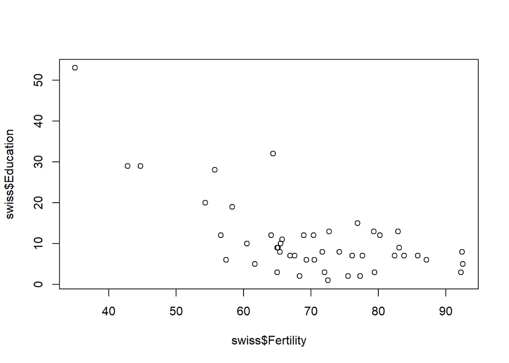

```r
plot(x = swiss$Fertility, y = swiss$Education)
```

追加の引数を指定することで，グラフのタイトル，X軸・Y軸のラベル，マーカーの種類などを変更できる．

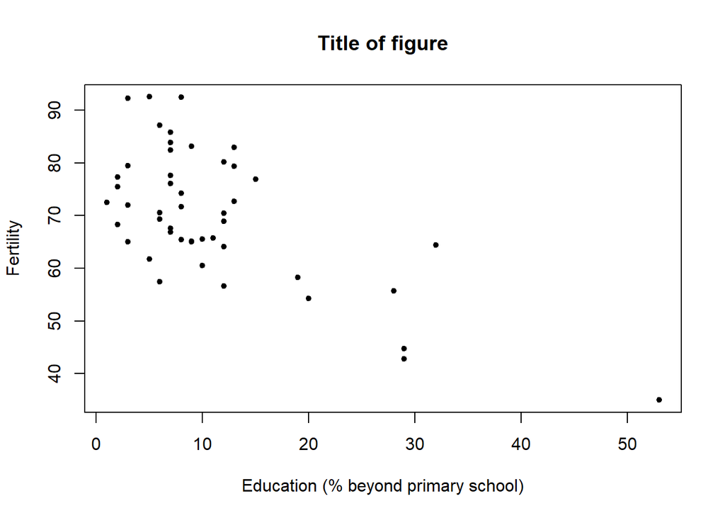

```r
plot(x = swiss$Education, y = swiss$Fertility, pch = 20,
     main = "Title of figure", xlab = "Education (% beyond primary school)", ylab = "Fertility")
```

複数のパネルを並べる場合は `par(mfrow = c(行数, 列数))` を実行してから `plot` コマンドを実行する．

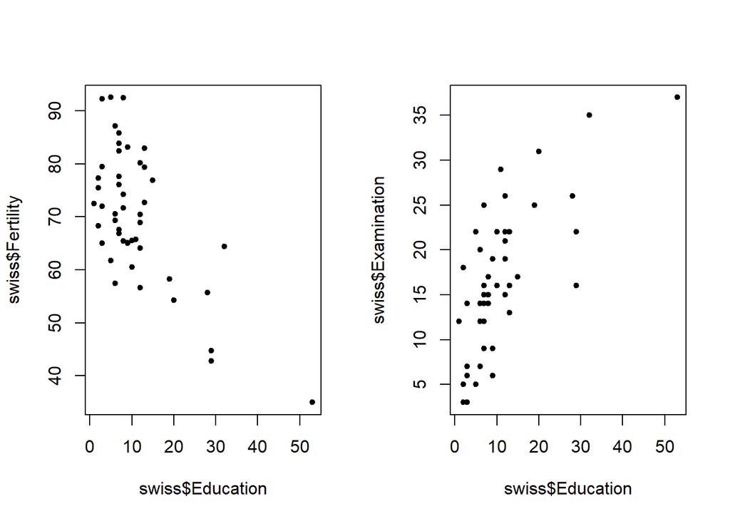

```r
par(mfrow = c(1, 2))
plot(x = swiss$Education, y = swiss$Fertility, pch = 20)
plot(x = swiss$Education, y = swiss$Examination, pch = 20)
```

Tips: `plot` 周りで何らかのエラーが生じたら，`dev.off()` で一旦描画デバイスを閉じるとうまくいくことがある．

# 4 Loading CSV file / CSVファイルを読み込む

例としてタイタニック号の乗客データ `titanic3_csv.csv` を読み込む．

元データは http://biostat.mc.vanderbilt.edu/DataSets から取得したもので，名前などの一部変数を除外している．

参照：[Titanic：タイタニック号乗客者の生存状況（年齢や性別などの13項目）の表形式データセット](https://atmarkit.itmedia.co.jp/ait/articles/2007/02/news016.html)

- pclass： 旅客クラス
- sibsp： 同船する兄弟（siblings）と配偶者（spouses）の数
- parch： 同船する親（parents）と子供（children）の数
- embarked： 出港地（C＝Cherbourg, Q＝Queenstown, S＝Southampton）

## 4.1 read.csv

Step 1. 授業のMoodleページまたは [GitHub](https://github.com/kurodaecon/bs/blob/main/data/titanic3_csv.csv) から CSV ファイルをダウンロードして適当なフォルダに保存する． たとえばCドライブ直下の「ws_stat」(workspace for statistics) フォルダに保存する．

Step 2. `setwd` 関数を使って保存したフォルダを作業ディレクトリとして指定する． `getwd` 関数で指定された作業ディレクトリを確認できる（カッコの中には何も書かない）．

Step 3. `read.csv` 関数でファイル名を引数として指定して読み込む．

```r
setwd("c://ws_stat")  # set working directory
getwd()  # get working directory
```

```
## [1] "c:/ws_stat"
```

```r
titanic <- read.csv("titanic3_csv.csv")
```

ファイルに日本語が含まれるとエラーが出る場合があるので，初心者のうちは日本語を含めずにファイルを作成・使用するのがおすすめ．

## 4.2 read.csv + file.choose

If the working directory settings do not work, execute the following line to load the CSV file. The “Select File” screen will appear, from which you can select the CSV file to be read.

作業ディレクトリの設定がうまくできない場合は，次の行を実行してCSVファイルを読み込む．実行すると「ファイルを選択」画面が出てきて，そこから読み込むCSVファイルを選択することができる．

```r
titanic <- read.csv(file.choose())
```

## 4.3 read.csv + external URL link

ウェブ上の CSV ファイルや TXT ファイルを直接読み込むこともできる．

```r
titanic <- read.csv("https://raw.githubusercontent.com/kurodaecon/bs/main/data/titanic3_csv.csv")
```

## 4.4 Data overview / データの概観

先ほど取り上げた `str` 関数を利用してデータフレームの構造を確認したり，`head` 関数を利用して最初の数行（デフォルトは6行）のみを表示させる．

```r
str(titanic)
```

```
## 'data.frame':    1309 obs. of  8 variables:
##  $ pclass  : int  1 1 1 1 1 1 1 1 1 1 ...
##  $ survived: int  1 1 0 0 0 1 1 0 1 0 ...
##  $ sex     : chr  "female" "male" "female" "male" ...
##  $ age     : num  29 0.92 2 30 25 48 63 39 53 71 ...
##  $ sibsp   : int  0 1 1 1 1 0 1 0 2 0 ...
##  $ parch   : int  0 2 2 2 2 0 0 0 0 0 ...
##  $ fare    : num  211 152 152 152 152 ...
##  $ embarked: chr  "S" "S" "S" "S" ...
```

```r
head(titanic)
```

```
##   pclass survived    sex   age sibsp parch     fare embarked
## 1      1        1 female 29.00     0     0 211.3375        S
## 2      1        1   male  0.92     1     2 151.5500        S
## 3      1        0 female  2.00     1     2 151.5500        S
## 4      1        0   male 30.00     1     2 151.5500        S
## 5      1        0 female 25.00     1     2 151.5500        S
## 6      1        1   male 48.00     0     0  26.5500        S
```

## 4.5 Output file / ファイルを出力

Rで加工したデータセットなどを CSV などのファイル形式で出力することができる．

### 4.5.1 Case 1. 既に作業ディレクトリを指定している場合

先ほど `setwd` で指定した作業ディレクトリに出力される．

```r
titanic_head <- head(titanic)
write.csv(titanic_head, "titanic_first_6_rows.csv")
```

### 4.5.2 Case 2. 作業ディレクトリを指定していない場合

Case 1 のコードを実行するとデフォルトで指定されている作業ディレクトリに出力される． デフォルトのディレクトリは先述のとおり `getwd()` で確認できる．

### 4.5.3 Case 3. 指定した作業ディレクトリとは別のフォルダに保存する場合

先に保存先フォルダを作成する（例：ws_stat 直下の new_dir フォルダ）．

```r
titanic_head <- head(titanic)
write.csv(titanic_head, "c://ws_stat/new_dir/titanic_first_6_rows.csv")
```

.